# Risk Factor Analysis

## Outcome Variable

**Outcome Variable:** ever_swasted

## Predictor Variables

**Intervention Variable:** birthlen

**Adjustment Set:**

- arm
- sex
- W_mage
- meducyrs
- feducyrs
- vagbrth
- single
- brthmon
- W_parity
- delta_W_mage
- delta_meducyrs
- delta_feducyrs
- delta_vagbrth
- delta_single
- delta_brthmon
- delta_W_parity

## Stratifying Variables

The analysis was stratified on these variable(s):

- agecat
- studyid
- country

## Data Summary

| agecat | studyid | country | birthlen | ever_swasted | n_cell | n |
| --- | --- | --- | --- | --- | --- | --- |
| 0-24 months (no birth wast) | ki0047075b-MAL-ED | BANGLADESH | >=50 cm | 0 | 26 | 256 |
| 0-24 months (no birth wast) | ki0047075b-MAL-ED | BANGLADESH | >=50 cm | 1 | 3 | 256 |
| 0-24 months (no birth wast) | ki0047075b-MAL-ED | BANGLADESH | <48 cm | 0 | 136 | 256 |
| 0-24 months (no birth wast) | ki0047075b-MAL-ED | BANGLADESH | <48 cm | 1 | 6 | 256 |
| 0-24 months (no birth wast) | ki0047075b-MAL-ED | BANGLADESH | [48-50) cm | 0 | 82 | 256 |
| 0-24 months (no birth wast) | ki0047075b-MAL-ED | BANGLADESH | [48-50) cm | 1 | 3 | 256 |
| 0-24 months (no birth wast) | ki0047075b-MAL-ED | BRAZIL | >=50 cm | 0 | 32 | 191 |
| 0-24 months (no birth wast) | ki0047075b-MAL-ED | BRAZIL | >=50 cm | 1 | 2 | 191 |
| 0-24 months (no birth wast) | ki0047075b-MAL-ED | BRAZIL | <48 cm | 0 | 80 | 191 |
| 0-24 months (no birth wast) | ki0047075b-MAL-ED | BRAZIL | <48 cm | 1 | 0 | 191 |
| 0-24 months (no birth wast) | ki0047075b-MAL-ED | BRAZIL | [48-50) cm | 0 | 76 | 191 |
| 0-24 months (no birth wast) | ki0047075b-MAL-ED | BRAZIL | [48-50) cm | 1 | 1 | 191 |
| 0-24 months (no birth wast) | ki0047075b-MAL-ED | INDIA | >=50 cm | 0 | 24 | 203 |
| 0-24 months (no birth wast) | ki0047075b-MAL-ED | INDIA | >=50 cm | 1 | 1 | 203 |
| 0-24 months (no birth wast) | ki0047075b-MAL-ED | INDIA | <48 cm | 0 | 103 | 203 |
| 0-24 months (no birth wast) | ki0047075b-MAL-ED | INDIA | <48 cm | 1 | 3 | 203 |
| 0-24 months (no birth wast) | ki0047075b-MAL-ED | INDIA | [48-50) cm | 0 | 69 | 203 |
| 0-24 months (no birth wast) | ki0047075b-MAL-ED | INDIA | [48-50) cm | 1 | 3 | 203 |
| 0-24 months (no birth wast) | ki0047075b-MAL-ED | NEPAL | >=50 cm | 0 | 38 | 173 |
| 0-24 months (no birth wast) | ki0047075b-MAL-ED | NEPAL | >=50 cm | 1 | 0 | 173 |
| 0-24 months (no birth wast) | ki0047075b-MAL-ED | NEPAL | <48 cm | 0 | 69 | 173 |
| 0-24 months (no birth wast) | ki0047075b-MAL-ED | NEPAL | <48 cm | 1 | 0 | 173 |
| 0-24 months (no birth wast) | ki0047075b-MAL-ED | NEPAL | [48-50) cm | 0 | 66 | 173 |
| 0-24 months (no birth wast) | ki0047075b-MAL-ED | NEPAL | [48-50) cm | 1 | 0 | 173 |
| 0-24 months (no birth wast) | ki0047075b-MAL-ED | PERU | >=50 cm | 0 | 33 | 288 |
| 0-24 months (no birth wast) | ki0047075b-MAL-ED | PERU | >=50 cm | 1 | 1 | 288 |
| 0-24 months (no birth wast) | ki0047075b-MAL-ED | PERU | <48 cm | 0 | 140 | 288 |
| 0-24 months (no birth wast) | ki0047075b-MAL-ED | PERU | <48 cm | 1 | 2 | 288 |
| 0-24 months (no birth wast) | ki0047075b-MAL-ED | PERU | [48-50) cm | 0 | 112 | 288 |
| 0-24 months (no birth wast) | ki0047075b-MAL-ED | PERU | [48-50) cm | 1 | 0 | 288 |

[output cut: 306 more lines]

The following strata were considered:

- agecat: 0-24 months (no birth wast), studyid: ki0047075b-MAL-ED, country: BANGLADESH
- agecat: 0-24 months (no birth wast), studyid: ki0047075b-MAL-ED, country: BRAZIL
- agecat: 0-24 months (no birth wast), studyid: ki0047075b-MAL-ED, country: INDIA
- agecat: 0-24 months (no birth wast), studyid: ki0047075b-MAL-ED, country: NEPAL
- agecat: 0-24 months (no birth wast), studyid: ki0047075b-MAL-ED, country: PERU
- agecat: 0-24 months (no birth wast), studyid: ki0047075b-MAL-ED, country: SOUTH AFRICA
- agecat: 0-24 months (no birth wast), studyid: ki0047075b-MAL-ED, country: TANZANIA, UNITED REPUBLIC OF
- agecat: 0-24 months (no birth wast), studyid: ki1000108-CMC-V-BCS-2002, country: INDIA
- agecat: 0-24 months (no birth wast), studyid: ki1000108-IRC, country: INDIA
- agecat: 0-24 months (no birth wast), studyid: ki1000109-EE, country: PAKISTAN
- agecat: 0-24 months (no birth wast), studyid: ki1000109-ResPak, country: PAKISTAN
- agecat: 0-24 months (no birth wast), studyid: ki1000304b-SAS-CompFeed, country: INDIA
- agecat: 0-24 months (no birth wast), studyid: ki1017093-NIH-Birth, country: BANGLADESH
- agecat: 0-24 months (no birth wast), studyid: ki1017093b-PROVIDE, country: BANGLADESH
- agecat: 0-24 months (no birth wast), studyid: ki1017093c-NIH-Crypto, country: BANGLADESH
- agecat: 0-24 months (no birth wast), studyid: ki1101329-Keneba, country: GAMBIA
- agecat: 0-24 months (no birth wast), studyid: ki1114097-CMIN, country: BANGLADESH
- agecat: 0-24 months (no birth wast), studyid: ki1114097-CMIN, country: BRAZIL
- agecat: 0-24 months (no birth wast), studyid: ki1114097-CMIN, country: GUINEA-BISSAU
- agecat: 0-24 months (no birth wast), studyid: ki1114097-CMIN, country: PERU
- agecat: 0-24 months (no birth wast), studyid: ki1114097-CONTENT, country: PERU
- agecat: 0-24 months (no birth wast), studyid: ki1119695-PROBIT, country: BELARUS
- agecat: 0-24 months (no birth wast), studyid: ki1126311-ZVITAMBO, country: ZIMBABWE
- agecat: 0-24 months (no birth wast), studyid: ki1135781-COHORTS, country: GUATEMALA
- agecat: 0-24 months (no birth wast), studyid: ki1135781-COHORTS, country: INDIA
- agecat: 0-24 months (no birth wast), studyid: ki1135781-COHORTS, country: PHILIPPINES
- agecat: 0-24 months (no birth wast), studyid: kiGH5241-JiVitA-3, country: BANGLADESH
- agecat: 0-24 months (no birth wast), studyid: kiGH5241-JiVitA-4, country: BANGLADESH
- agecat: 6-24 months, studyid: ki0047075b-MAL-ED, country: BANGLADESH
- agecat: 6-24 months, studyid: ki0047075b-MAL-ED, country: BRAZIL
- agecat: 6-24 months, studyid: ki0047075b-MAL-ED, country: INDIA
- agecat: 6-24 months, studyid: ki0047075b-MAL-ED, country: NEPAL
- agecat: 6-24 months, studyid: ki0047075b-MAL-ED, country: PERU
- agecat: 6-24 months, studyid: ki0047075b-MAL-ED, country: SOUTH AFRICA
- agecat: 6-24 months, studyid: ki0047075b-MAL-ED, country: TANZANIA, UNITED REPUBLIC OF
- agecat: 6-24 months, studyid: ki1000108-CMC-V-BCS-2002, country: INDIA
- agecat: 6-24 months, studyid: ki1000108-IRC, country: INDIA
- agecat: 6-24 months, studyid: ki1000109-EE, country: PAKISTAN
- agecat: 6-24 months, studyid: ki1000109-ResPak, country: PAKISTAN
- agecat: 6-24 months, studyid: ki1000304b-SAS-CompFeed, country: INDIA
- agecat: 6-24 months, studyid: ki1017093-NIH-Birth, country: BANGLADESH
- agecat: 6-24 months, studyid: ki1017093b-PROVIDE, country: BANGLADESH
- agecat: 6-24 months, studyid: ki1017093c-NIH-Crypto, country: BANGLADESH
- agecat: 6-24 months, studyid: ki1101329-Keneba, country: GAMBIA
- agecat: 6-24 months, studyid: ki1114097-CMIN, country: BANGLADESH
- agecat: 6-24 months, studyid: ki1114097-CMIN, country: BRAZIL
- agecat: 6-24 months, studyid: ki1114097-CMIN, country: GUINEA-BISSAU
- agecat: 6-24 months, studyid: ki1114097-CMIN, country: PERU
- agecat: 6-24 months, studyid: ki1114097-CONTENT, country: PERU
- agecat: 6-24 months, studyid: ki1119695-PROBIT, country: BELARUS
- agecat: 6-24 months, studyid: ki1126311-ZVITAMBO, country: ZIMBABWE
- agecat: 6-24 months, studyid: ki1135781-COHORTS, country: GUATEMALA
- agecat: 6-24 months, studyid: ki1135781-COHORTS, country: INDIA
- agecat: 6-24 months, studyid: ki1135781-COHORTS, country: PHILIPPINES
- agecat: 6-24 months, studyid: kiGH5241-JiVitA-3, country: BANGLADESH
- agecat: 6-24 months, studyid: kiGH5241-JiVitA-4, country: BANGLADESH

### Dropped Strata

Some strata were dropped due to rare outcomes:

- agecat: 0-24 months (no birth wast), studyid: ki0047075b-MAL-ED, country: BANGLADESH
- agecat: 0-24 months (no birth wast), studyid: ki0047075b-MAL-ED, country: BRAZIL
- agecat: 0-24 months (no birth wast), studyid: ki0047075b-MAL-ED, country: INDIA
- agecat: 0-24 months (no birth wast), studyid: ki0047075b-MAL-ED, country: NEPAL
- agecat: 0-24 months (no birth wast), studyid: ki0047075b-MAL-ED, country: PERU
- agecat: 0-24 months (no birth wast), studyid: ki0047075b-MAL-ED, country: SOUTH AFRICA
- agecat: 0-24 months (no birth wast), studyid: ki0047075b-MAL-ED, country: TANZANIA, UNITED REPUBLIC OF
- agecat: 0-24 months (no birth wast), studyid: ki1000108-CMC-V-BCS-2002, country: INDIA
- agecat: 0-24 months (no birth wast), studyid: ki1000109-EE, country: PAKISTAN
- agecat: 0-24 months (no birth wast), studyid: ki1000109-ResPak, country: PAKISTAN
- agecat: 0-24 months (no birth wast), studyid: ki1017093-NIH-Birth, country: BANGLADESH
- agecat: 0-24 months (no birth wast), studyid: ki1017093b-PROVIDE, country: BANGLADESH
- agecat: 0-24 months (no birth wast), studyid: ki1017093c-NIH-Crypto, country: BANGLADESH
- agecat: 0-24 months (no birth wast), studyid: ki1114097-CMIN, country: BANGLADESH
- agecat: 0-24 months (no birth wast), studyid: ki1114097-CMIN, country: BRAZIL
- agecat: 0-24 months (no birth wast), studyid: ki1114097-CMIN, country: GUINEA-BISSAU
- agecat: 0-24 months (no birth wast), studyid: ki1114097-CMIN, country: PERU
- agecat: 0-24 months (no birth wast), studyid: ki1114097-CONTENT, country: PERU
- agecat: 0-24 months (no birth wast), studyid: ki1119695-PROBIT, country: BELARUS
- agecat: 0-24 months (no birth wast), studyid: ki1135781-COHORTS, country: GUATEMALA
- agecat: 6-24 months, studyid: ki0047075b-MAL-ED, country: BANGLADESH
- agecat: 6-24 months, studyid: ki0047075b-MAL-ED, country: BRAZIL
- agecat: 6-24 months, studyid: ki0047075b-MAL-ED, country: INDIA
- agecat: 6-24 months, studyid: ki0047075b-MAL-ED, country: NEPAL
- agecat: 6-24 months, studyid: ki0047075b-MAL-ED, country: PERU
- agecat: 6-24 months, studyid: ki0047075b-MAL-ED, country: SOUTH AFRICA
- agecat: 6-24 months, studyid: ki0047075b-MAL-ED, country: TANZANIA, UNITED REPUBLIC OF
- agecat: 6-24 months, studyid: ki1000108-CMC-V-BCS-2002, country: INDIA
- agecat: 6-24 months, studyid: ki1000109-EE, country: PAKISTAN
- agecat: 6-24 months, studyid: ki1000109-ResPak, country: PAKISTAN
- agecat: 6-24 months, studyid: ki1017093-NIH-Birth, country: BANGLADESH
- agecat: 6-24 months, studyid: ki1017093b-PROVIDE, country: BANGLADESH
- agecat: 6-24 months, studyid: ki1017093c-NIH-Crypto, country: BANGLADESH
- agecat: 6-24 months, studyid: ki1114097-CMIN, country: BANGLADESH
- agecat: 6-24 months, studyid: ki1114097-CMIN, country: BRAZIL
- agecat: 6-24 months, studyid: ki1114097-CMIN, country: GUINEA-BISSAU
- agecat: 6-24 months, studyid: ki1114097-CMIN, country: PERU
- agecat: 6-24 months, studyid: ki1114097-CONTENT, country: PERU
- agecat: 6-24 months, studyid: ki1119695-PROBIT, country: BELARUS
- agecat: 6-24 months, studyid: ki1135781-COHORTS, country: GUATEMALA

## Methods Detail

We’re interested in the causal parameters $E[Y_a]$ for all values of $a \in \mathcal{A}$. These parameters represent the mean outcome if, possibly contrary to fact, we intervened to set all units to have $A=a$. Under the randomization and positivity assumptions, these are identified by the statistical parameters $\psi_a=E_W[E_{Y|A,W}(Y|A=a,W)]$. In addition, we’re interested in the mean of $Y$, $E[Y]$ under no intervention (the observed mean). We will estimate these parameters by using SuperLearner to fit the relevant likelihood factors – $E_{Y|A,W}(Y|A=a,W)$ and $p(A=a|W)$, and then updating our likelihood fit using a joint TMLE.

For unadjusted analyses ($W=\{\}$), initial likelihoods were estimated using Lrnr_glm to estimate the simple $E(Y|A)$ and Lrnr_mean to estimate $p(A)$. For adjusted analyses, a small library containing Lrnr_glmnet, Lrnr_xgboost, and Lrnr_mean was used.

Having estimated these parameters, we will then use the delta method to estimate relative risks and attributable risks relative to a prespecified baseline level of $A$.

# Results Detail

## Results Plots

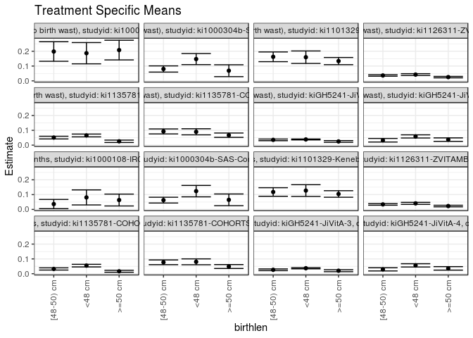

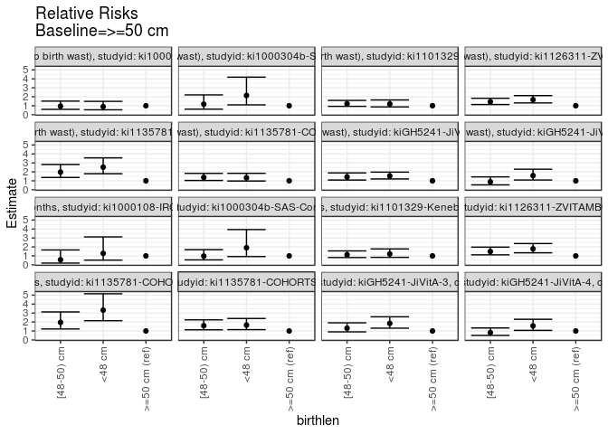

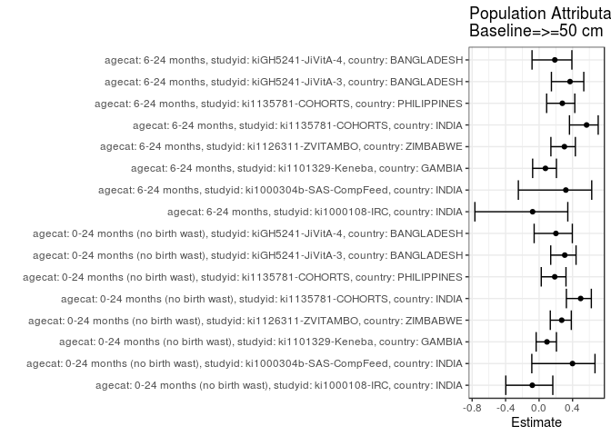

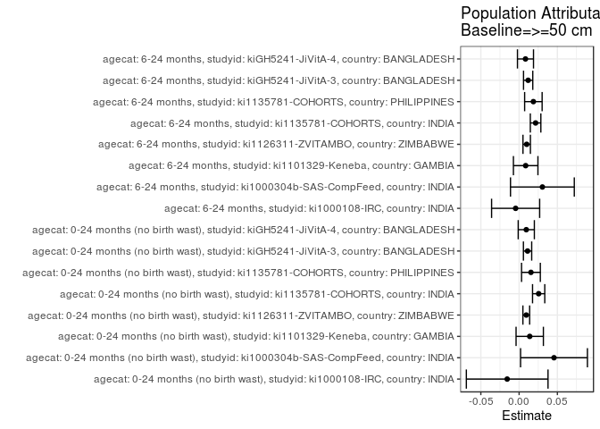

## Results Table

### Parameter: TSM

| agecat | studyid | country | intervention_level | baseline_level | estimate | ci_lower | ci_upper |
| --- | --- | --- | --- | --- | --- | --- | --- |
| 0-24 months (no birth wast) | ki1000108-IRC | INDIA | >=50 cm | NA | 0.2078910 | 0.1413153 | 0.2744666 |
| 0-24 months (no birth wast) | ki1000108-IRC | INDIA | <48 cm | NA | 0.1869593 | 0.1150641 | 0.2588545 |
| 0-24 months (no birth wast) | ki1000108-IRC | INDIA | [48-50) cm | NA | 0.1982154 | 0.1321625 | 0.2642683 |
| 0-24 months (no birth wast) | ki1000304b-SAS-CompFeed | INDIA | >=50 cm | NA | 0.0685928 | 0.0283638 | 0.1088219 |
| 0-24 months (no birth wast) | ki1000304b-SAS-CompFeed | INDIA | <48 cm | NA | 0.1471442 | 0.1097575 | 0.1845309 |
| 0-24 months (no birth wast) | ki1000304b-SAS-CompFeed | INDIA | [48-50) cm | NA | 0.0802033 | 0.0592320 | 0.1011746 |
| 0-24 months (no birth wast) | ki1101329-Keneba | GAMBIA | >=50 cm | NA | 0.1336082 | 0.1093492 | 0.1578673 |
| 0-24 months (no birth wast) | ki1101329-Keneba | GAMBIA | <48 cm | NA | 0.1598349 | 0.1177025 | 0.2019672 |
| 0-24 months (no birth wast) | ki1101329-Keneba | GAMBIA | [48-50) cm | NA | 0.1624797 | 0.1297296 | 0.1952297 |
| 0-24 months (no birth wast) | ki1126311-ZVITAMBO | ZIMBABWE | >=50 cm | NA | 0.0252695 | 0.0203757 | 0.0301632 |
| 0-24 months (no birth wast) | ki1126311-ZVITAMBO | ZIMBABWE | <48 cm | NA | 0.0422750 | 0.0361179 | 0.0484321 |
| 0-24 months (no birth wast) | ki1126311-ZVITAMBO | ZIMBABWE | [48-50) cm | NA | 0.0364381 | 0.0312954 | 0.0415809 |
| 0-24 months (no birth wast) | ki1135781-COHORTS | INDIA | >=50 cm | NA | 0.0258714 | 0.0178067 | 0.0339360 |
| 0-24 months (no birth wast) | ki1135781-COHORTS | INDIA | <48 cm | NA | 0.0653627 | 0.0559079 | 0.0748176 |
| 0-24 months (no birth wast) | ki1135781-COHORTS | INDIA | [48-50) cm | NA | 0.0509574 | 0.0418588 | 0.0600560 |
| 0-24 months (no birth wast) | ki1135781-COHORTS | PHILIPPINES | >=50 cm | NA | 0.0672443 | 0.0525774 | 0.0819113 |
| 0-24 months (no birth wast) | ki1135781-COHORTS | PHILIPPINES | <48 cm | NA | 0.0900435 | 0.0695034 | 0.1105836 |
| 0-24 months (no birth wast) | ki1135781-COHORTS | PHILIPPINES | [48-50) cm | NA | 0.0926757 | 0.0758793 | 0.1094720 |
| 0-24 months (no birth wast) | kiGH5241-JiVitA-3 | BANGLADESH | >=50 cm | NA | 0.0249532 | 0.0191342 | 0.0307722 |
| 0-24 months (no birth wast) | kiGH5241-JiVitA-3 | BANGLADESH | <48 cm | NA | 0.0384234 | 0.0351746 | 0.0416722 |
| 0-24 months (no birth wast) | kiGH5241-JiVitA-3 | BANGLADESH | [48-50) cm | NA | 0.0356508 | 0.0300485 | 0.0412532 |
| 0-24 months (no birth wast) | kiGH5241-JiVitA-4 | BANGLADESH | >=50 cm | NA | 0.0372324 | 0.0253584 | 0.0491065 |
| 0-24 months (no birth wast) | kiGH5241-JiVitA-4 | BANGLADESH | <48 cm | NA | 0.0588229 | 0.0482369 | 0.0694089 |
| 0-24 months (no birth wast) | kiGH5241-JiVitA-4 | BANGLADESH | [48-50) cm | NA | 0.0329761 | 0.0209290 | 0.0450233 |
| 6-24 months | ki1000108-IRC | INDIA | >=50 cm | NA | 0.0633803 | 0.0232549 | 0.1035056 |
| 6-24 months | ki1000108-IRC | INDIA | <48 cm | NA | 0.0810811 | 0.0302369 | 0.1319252 |
| 6-24 months | ki1000108-IRC | INDIA | [48-50) cm | NA | 0.0362319 | 0.0050145 | 0.0674493 |
| 6-24 months | ki1000304b-SAS-CompFeed | INDIA | >=50 cm | NA | 0.0647868 | 0.0251855 | 0.1043881 |
| 6-24 months | ki1000304b-SAS-CompFeed | INDIA | <48 cm | NA | 0.1235847 | 0.0850552 | 0.1621142 |
| 6-24 months | ki1000304b-SAS-CompFeed | INDIA | [48-50) cm | NA | 0.0627962 | 0.0433150 | 0.0822775 |
| 6-24 months | ki1101329-Keneba | GAMBIA | >=50 cm | NA | 0.1044091 | 0.0823566 | 0.1264617 |
| 6-24 months | ki1101329-Keneba | GAMBIA | <48 cm | NA | 0.1272929 | 0.0876326 | 0.1669533 |
| 6-24 months | ki1101329-Keneba | GAMBIA | [48-50) cm | NA | 0.1176994 | 0.0887853 | 0.1466135 |
| 6-24 months | ki1126311-ZVITAMBO | ZIMBABWE | >=50 cm | NA | 0.0228361 | 0.0175121 | 0.0281601 |
| 6-24 months | ki1126311-ZVITAMBO | ZIMBABWE | <48 cm | NA | 0.0408241 | 0.0341215 | 0.0475267 |
| 6-24 months | ki1126311-ZVITAMBO | ZIMBABWE | [48-50) cm | NA | 0.0339694 | 0.0284250 | 0.0395138 |
| 6-24 months | ki1135781-COHORTS | INDIA | >=50 cm | NA | 0.0164112 | 0.0097181 | 0.0231043 |
| 6-24 months | ki1135781-COHORTS | INDIA | <48 cm | NA | 0.0545697 | 0.0457584 | 0.0633810 |
| 6-24 months | ki1135781-COHORTS | INDIA | [48-50) cm | NA | 0.0320988 | 0.0247027 | 0.0394948 |
| 6-24 months | ki1135781-COHORTS | PHILIPPINES | >=50 cm | NA | 0.0484577 | 0.0352939 | 0.0616216 |
| 6-24 months | ki1135781-COHORTS | PHILIPPINES | <48 cm | NA | 0.0803370 | 0.0604404 | 0.1002335 |
| 6-24 months | ki1135781-COHORTS | PHILIPPINES | [48-50) cm | NA | 0.0770603 | 0.0610430 | 0.0930776 |
| 6-24 months | kiGH5241-JiVitA-3 | BANGLADESH | >=50 cm | NA | 0.0201330 | 0.0135499 | 0.0267161 |
| 6-24 months | kiGH5241-JiVitA-3 | BANGLADESH | <48 cm | NA | 0.0370269 | 0.0330810 | 0.0409729 |
| 6-24 months | kiGH5241-JiVitA-3 | BANGLADESH | [48-50) cm | NA | 0.0263847 | 0.0206369 | 0.0321326 |
| 6-24 months | kiGH5241-JiVitA-4 | BANGLADESH | >=50 cm | NA | 0.0359395 | 0.0242367 | 0.0476423 |
| 6-24 months | kiGH5241-JiVitA-4 | BANGLADESH | <48 cm | NA | 0.0563236 | 0.0453497 | 0.0672975 |
| 6-24 months | kiGH5241-JiVitA-4 | BANGLADESH | [48-50) cm | NA | 0.0294249 | 0.0187418 | 0.0401080 |

### Parameter: E(Y)

| agecat | studyid | country | intervention_level | baseline_level | estimate | ci_lower | ci_upper |
| --- | --- | --- | --- | --- | --- | --- | --- |
| 0-24 months (no birth wast) | ki1000108-IRC | INDIA | NA | NA | 0.1923077 | 0.1531430 | 0.2314724 |
| 0-24 months (no birth wast) | ki1000304b-SAS-CompFeed | INDIA | NA | NA | 0.1141706 | 0.0903032 | 0.1380379 |
| 0-24 months (no birth wast) | ki1101329-Keneba | GAMBIA | NA | NA | 0.1474774 | 0.1297967 | 0.1651581 |
| 0-24 months (no birth wast) | ki1126311-ZVITAMBO | ZIMBABWE | NA | NA | 0.0346234 | 0.0315379 | 0.0377089 |
| 0-24 months (no birth wast) | ki1135781-COHORTS | INDIA | NA | NA | 0.0514063 | 0.0459957 | 0.0568168 |
| 0-24 months (no birth wast) | ki1135781-COHORTS | PHILIPPINES | NA | NA | 0.0826968 | 0.0728574 | 0.0925361 |
| 0-24 months (no birth wast) | kiGH5241-JiVitA-3 | BANGLADESH | NA | NA | 0.0359842 | 0.0333710 | 0.0385974 |
| 0-24 months (no birth wast) | kiGH5241-JiVitA-4 | BANGLADESH | NA | NA | 0.0465950 | 0.0398949 | 0.0532951 |
| 6-24 months | ki1000108-IRC | INDIA | NA | NA | 0.0588235 | 0.0354714 | 0.0821757 |
| 6-24 months | ki1000304b-SAS-CompFeed | INDIA | NA | NA | 0.0952035 | 0.0698704 | 0.1205365 |
| 6-24 months | ki1101329-Keneba | GAMBIA | NA | NA | 0.1129792 | 0.0968836 | 0.1290747 |
| 6-24 months | ki1126311-ZVITAMBO | ZIMBABWE | NA | NA | 0.0327342 | 0.0293418 | 0.0361265 |
| 6-24 months | ki1135781-COHORTS | INDIA | NA | NA | 0.0379316 | 0.0331642 | 0.0426990 |
| 6-24 months | ki1135781-COHORTS | PHILIPPINES | NA | NA | 0.0670949 | 0.0578297 | 0.0763601 |
| 6-24 months | kiGH5241-JiVitA-3 | BANGLADESH | NA | NA | 0.0319406 | 0.0290104 | 0.0348708 |
| 6-24 months | kiGH5241-JiVitA-4 | BANGLADESH | NA | NA | 0.0442557 | 0.0375111 | 0.0510003 |

### Parameter: RR

| agecat | studyid | country | intervention_level | baseline_level | estimate | ci_lower | ci_upper |
| --- | --- | --- | --- | --- | --- | --- | --- |
| 0-24 months (no birth wast) | ki1000108-IRC | INDIA | >=50 cm | >=50 cm | 1.0000000 | 1.0000000 | 1.000000 |
| 0-24 months (no birth wast) | ki1000108-IRC | INDIA | <48 cm | >=50 cm | 0.8993143 | 0.5441648 | 1.486252 |
| 0-24 months (no birth wast) | ki1000108-IRC | INDIA | [48-50) cm | >=50 cm | 0.9534586 | 0.5997242 | 1.515836 |
| 0-24 months (no birth wast) | ki1000304b-SAS-CompFeed | INDIA | >=50 cm | >=50 cm | 1.0000000 | 1.0000000 | 1.000000 |
| 0-24 months (no birth wast) | ki1000304b-SAS-CompFeed | INDIA | <48 cm | >=50 cm | 2.1451830 | 1.0986057 | 4.188773 |
| 0-24 months (no birth wast) | ki1000304b-SAS-CompFeed | INDIA | [48-50) cm | >=50 cm | 1.1692657 | 0.6196455 | 2.206394 |
| 0-24 months (no birth wast) | ki1101329-Keneba | GAMBIA | >=50 cm | >=50 cm | 1.0000000 | 1.0000000 | 1.000000 |
| 0-24 months (no birth wast) | ki1101329-Keneba | GAMBIA | <48 cm | >=50 cm | 1.1962953 | 0.8691589 | 1.646560 |
| 0-24 months (no birth wast) | ki1101329-Keneba | GAMBIA | [48-50) cm | >=50 cm | 1.2160903 | 0.9275724 | 1.594351 |
| 0-24 months (no birth wast) | ki1126311-ZVITAMBO | ZIMBABWE | >=50 cm | >=50 cm | 1.0000000 | 1.0000000 | 1.000000 |
| 0-24 months (no birth wast) | ki1126311-ZVITAMBO | ZIMBABWE | <48 cm | >=50 cm | 1.6729688 | 1.3129887 | 2.131644 |
| 0-24 months (no birth wast) | ki1126311-ZVITAMBO | ZIMBABWE | [48-50) cm | >=50 cm | 1.4419823 | 1.1347184 | 1.832449 |
| 0-24 months (no birth wast) | ki1135781-COHORTS | INDIA | >=50 cm | >=50 cm | 1.0000000 | 1.0000000 | 1.000000 |
| 0-24 months (no birth wast) | ki1135781-COHORTS | INDIA | <48 cm | >=50 cm | 2.5264495 | 1.7919216 | 3.562068 |
| 0-24 months (no birth wast) | ki1135781-COHORTS | INDIA | [48-50) cm | >=50 cm | 1.9696447 | 1.3753710 | 2.820694 |
| 0-24 months (no birth wast) | ki1135781-COHORTS | PHILIPPINES | >=50 cm | >=50 cm | 1.0000000 | 1.0000000 | 1.000000 |
| 0-24 months (no birth wast) | ki1135781-COHORTS | PHILIPPINES | <48 cm | >=50 cm | 1.3390495 | 0.9768393 | 1.835566 |
| 0-24 months (no birth wast) | ki1135781-COHORTS | PHILIPPINES | [48-50) cm | >=50 cm | 1.3781932 | 1.0382097 | 1.829511 |
| 0-24 months (no birth wast) | kiGH5241-JiVitA-3 | BANGLADESH | >=50 cm | >=50 cm | 1.0000000 | 1.0000000 | 1.000000 |
| 0-24 months (no birth wast) | kiGH5241-JiVitA-3 | BANGLADESH | <48 cm | >=50 cm | 1.5398192 | 1.2048619 | 1.967896 |
| 0-24 months (no birth wast) | kiGH5241-JiVitA-3 | BANGLADESH | [48-50) cm | >=50 cm | 1.4287079 | 1.0847302 | 1.881764 |
| 0-24 months (no birth wast) | kiGH5241-JiVitA-4 | BANGLADESH | >=50 cm | >=50 cm | 1.0000000 | 1.0000000 | 1.000000 |
| 0-24 months (no birth wast) | kiGH5241-JiVitA-4 | BANGLADESH | <48 cm | >=50 cm | 1.5798838 | 1.0894416 | 2.291112 |
| 0-24 months (no birth wast) | kiGH5241-JiVitA-4 | BANGLADESH | [48-50) cm | >=50 cm | 0.8856834 | 0.5449807 | 1.439382 |
| 6-24 months | ki1000108-IRC | INDIA | >=50 cm | >=50 cm | 1.0000000 | 1.0000000 | 1.000000 |
| 6-24 months | ki1000108-IRC | INDIA | <48 cm | >=50 cm | 1.2792793 | 0.5247750 | 3.118585 |
| 6-24 months | ki1000108-IRC | INDIA | [48-50) cm | >=50 cm | 0.5716586 | 0.1962438 | 1.665243 |
| 6-24 months | ki1000304b-SAS-CompFeed | INDIA | >=50 cm | >=50 cm | 1.0000000 | 1.0000000 | 1.000000 |
| 6-24 months | ki1000304b-SAS-CompFeed | INDIA | <48 cm | >=50 cm | 1.9075598 | 0.9242290 | 3.937103 |
| 6-24 months | ki1000304b-SAS-CompFeed | INDIA | [48-50) cm | >=50 cm | 0.9692751 | 0.5544781 | 1.694376 |
| 6-24 months | ki1101329-Keneba | GAMBIA | >=50 cm | >=50 cm | 1.0000000 | 1.0000000 | 1.000000 |
| 6-24 months | ki1101329-Keneba | GAMBIA | <48 cm | >=50 cm | 1.2191744 | 0.8372429 | 1.775334 |
| 6-24 months | ki1101329-Keneba | GAMBIA | [48-50) cm | >=50 cm | 1.1272903 | 0.8155849 | 1.558125 |
| 6-24 months | ki1126311-ZVITAMBO | ZIMBABWE | >=50 cm | >=50 cm | 1.0000000 | 1.0000000 | 1.000000 |
| 6-24 months | ki1126311-ZVITAMBO | ZIMBABWE | <48 cm | >=50 cm | 1.7877002 | 1.3441905 | 2.377544 |
| 6-24 months | ki1126311-ZVITAMBO | ZIMBABWE | [48-50) cm | >=50 cm | 1.4875293 | 1.1190770 | 1.977293 |
| 6-24 months | ki1135781-COHORTS | INDIA | >=50 cm | >=50 cm | 1.0000000 | 1.0000000 | 1.000000 |
| 6-24 months | ki1135781-COHORTS | INDIA | <48 cm | >=50 cm | 3.3251566 | 2.1446790 | 5.155395 |
| 6-24 months | ki1135781-COHORTS | INDIA | [48-50) cm | >=50 cm | 1.9559086 | 1.2245853 | 3.123979 |
| 6-24 months | ki1135781-COHORTS | PHILIPPINES | >=50 cm | >=50 cm | 1.0000000 | 1.0000000 | 1.000000 |
| 6-24 months | ki1135781-COHORTS | PHILIPPINES | <48 cm | >=50 cm | 1.6578780 | 1.1482531 | 2.393688 |
| 6-24 months | ki1135781-COHORTS | PHILIPPINES | [48-50) cm | >=50 cm | 1.5902579 | 1.1300832 | 2.237818 |
| 6-24 months | kiGH5241-JiVitA-3 | BANGLADESH | >=50 cm | >=50 cm | 1.0000000 | 1.0000000 | 1.000000 |
| 6-24 months | kiGH5241-JiVitA-3 | BANGLADESH | <48 cm | >=50 cm | 1.8391165 | 1.3090563 | 2.583807 |
| 6-24 months | kiGH5241-JiVitA-3 | BANGLADESH | [48-50) cm | >=50 cm | 1.3105224 | 0.8992798 | 1.909827 |
| 6-24 months | kiGH5241-JiVitA-4 | BANGLADESH | >=50 cm | >=50 cm | 1.0000000 | 1.0000000 | 1.000000 |
| 6-24 months | kiGH5241-JiVitA-4 | BANGLADESH | <48 cm | >=50 cm | 1.5671772 | 1.0662093 | 2.303529 |
| 6-24 months | kiGH5241-JiVitA-4 | BANGLADESH | [48-50) cm | >=50 cm | 0.8187348 | 0.5020470 | 1.335187 |

### Parameter: PAR

| agecat | studyid | country | intervention_level | baseline_level | estimate | ci_lower | ci_upper |
| --- | --- | --- | --- | --- | --- | --- | --- |
| 0-24 months (no birth wast) | ki1000108-IRC | INDIA | >=50 cm | NA | -0.0155833 | -0.0689270 | 0.0377605 |
| 0-24 months (no birth wast) | ki1000304b-SAS-CompFeed | INDIA | >=50 cm | NA | 0.0455777 | 0.0019169 | 0.0892386 |
| 0-24 months (no birth wast) | ki1101329-Keneba | GAMBIA | >=50 cm | NA | 0.0138691 | -0.0039728 | 0.0317111 |
| 0-24 months (no birth wast) | ki1126311-ZVITAMBO | ZIMBABWE | >=50 cm | NA | 0.0093539 | 0.0049536 | 0.0137541 |
| 0-24 months (no birth wast) | ki1135781-COHORTS | INDIA | >=50 cm | NA | 0.0255349 | 0.0175493 | 0.0335204 |
| 0-24 months (no birth wast) | ki1135781-COHORTS | PHILIPPINES | >=50 cm | NA | 0.0154524 | 0.0031964 | 0.0277085 |
| 0-24 months (no birth wast) | kiGH5241-JiVitA-3 | BANGLADESH | >=50 cm | NA | 0.0110310 | 0.0056253 | 0.0164367 |
| 0-24 months (no birth wast) | kiGH5241-JiVitA-4 | BANGLADESH | >=50 cm | NA | 0.0093626 | -0.0011886 | 0.0199137 |
| 6-24 months | ki1000108-IRC | INDIA | >=50 cm | NA | -0.0045568 | -0.0359562 | 0.0268427 |
| 6-24 months | ki1000304b-SAS-CompFeed | INDIA | >=50 cm | NA | 0.0304167 | -0.0112531 | 0.0720865 |
| 6-24 months | ki1101329-Keneba | GAMBIA | >=50 cm | NA | 0.0085700 | -0.0074382 | 0.0245783 |
| 6-24 months | ki1126311-ZVITAMBO | ZIMBABWE | >=50 cm | NA | 0.0098981 | 0.0050450 | 0.0147511 |
| 6-24 months | ki1135781-COHORTS | INDIA | >=50 cm | NA | 0.0215204 | 0.0146417 | 0.0283991 |
| 6-24 months | ki1135781-COHORTS | PHILIPPINES | >=50 cm | NA | 0.0186372 | 0.0072158 | 0.0300586 |
| 6-24 months | kiGH5241-JiVitA-3 | BANGLADESH | >=50 cm | NA | 0.0118076 | 0.0057694 | 0.0178458 |
| 6-24 months | kiGH5241-JiVitA-4 | BANGLADESH | >=50 cm | NA | 0.0083162 | -0.0021650 | 0.0187974 |

### Parameter: PAF

| agecat | studyid | country | intervention_level | baseline_level | estimate | ci_lower | ci_upper |
| --- | --- | --- | --- | --- | --- | --- | --- |
| 0-24 months (no birth wast) | ki1000108-IRC | INDIA | >=50 cm | NA | -0.0810330 | -0.3976227 | 0.1638427 |
| 0-24 months (no birth wast) | ki1000304b-SAS-CompFeed | INDIA | >=50 cm | NA | 0.3992074 | -0.0871215 | 0.6679748 |
| 0-24 months (no birth wast) | ki1101329-Keneba | GAMBIA | >=50 cm | NA | 0.0940425 | -0.0351213 | 0.2070891 |
| 0-24 months (no birth wast) | ki1126311-ZVITAMBO | ZIMBABWE | >=50 cm | NA | 0.2701613 | 0.1338453 | 0.3850238 |
| 0-24 months (no birth wast) | ki1135781-COHORTS | INDIA | >=50 cm | NA | 0.4967270 | 0.3260450 | 0.6241830 |
| 0-24 months (no birth wast) | ki1135781-COHORTS | PHILIPPINES | >=50 cm | NA | 0.1868567 | 0.0258195 | 0.3212735 |
| 0-24 months (no birth wast) | kiGH5241-JiVitA-3 | BANGLADESH | >=50 cm | NA | 0.3065511 | 0.1389068 | 0.4415572 |
| 0-24 months (no birth wast) | kiGH5241-JiVitA-4 | BANGLADESH | >=50 cm | NA | 0.2009348 | -0.0591664 | 0.3971625 |
| 6-24 months | ki1000108-IRC | INDIA | >=50 cm | NA | -0.0774648 | -0.7670506 | 0.3430124 |
| 6-24 months | ki1000304b-SAS-CompFeed | INDIA | >=50 cm | NA | 0.3194913 | -0.2478521 | 0.6288886 |
| 6-24 months | ki1101329-Keneba | GAMBIA | >=50 cm | NA | 0.0758550 | -0.0770474 | 0.2070507 |
| 6-24 months | ki1126311-ZVITAMBO | ZIMBABWE | >=50 cm | NA | 0.3023769 | 0.1410298 | 0.4334170 |
| 6-24 months | ki1135781-COHORTS | INDIA | >=50 cm | NA | 0.5673481 | 0.3629824 | 0.7061499 |
| 6-24 months | ki1135781-COHORTS | PHILIPPINES | >=50 cm | NA | 0.2777739 | 0.0902425 | 0.4266487 |
| 6-24 months | kiGH5241-JiVitA-3 | BANGLADESH | >=50 cm | NA | 0.3696740 | 0.1473305 | 0.5340389 |
| 6-24 months | kiGH5241-JiVitA-4 | BANGLADESH | >=50 cm | NA | 0.1879120 | -0.0843959 | 0.3918394 |